# Week1 - Tables Graphs

Aditya Maheshwari

2018-06-24

# Introduction

This notebook explores methods for visualizing and analyzing data in R using tables and graphs. The library used is called tidyverse, which is the standard for doing simple visualizations (and some complicated ones) in R. When there is not much data or the audience only is looking for overviews and summary information, graphs and tables are usually enough to get a point across. This notebook will use the Titanic Dataset from Kaggle as a starting point, and then do a “fun” challenge with Gapminder data.

The sections of this are: - Reading and Cleaning Data - Plotting Data - Summary Functions - Problems

# Important Packages and Link to Reference Book

The two important packages inside tidyverse (which is a set of packages) are “dplyr” and “ggplot2”.

```r
#install.packages("tidyverse")
#install.packages("dplyr", "ggplot2", "magrittr")

library(tidyverse)
```

The tidyverse book (filtering plotting and more): http://r4ds.had.co.nz/introduction.html

# Reading and Cleaning Data

Data can come from many sources - a csv works for smaller sized data while maybe an avro file (serialized) with a schema can work for larger amounts of data. R has many functions for reading external data and writing data from R to other softwares. Usually it is best to look them up for specific cases, but in many cases read.csv() and write.csv() are the more important ones. Use the help command to learn more about them.

Another very common problem with data is that it does not always come in a form that is easy to analyze. That is why it is important to reshuffle and filter and clean the data to meet relevant requirements. R is not the best language to actually clean data with - especially compared to languages that allow a user to easily open and modify file contents (C++, Python etc) are good. Also, there are specific programs for specific types of files (i.e Excel is good for xlsx and csv or Tableau is good for twb).

There is no real scientific method for cleaning data or trying to decode it so it can be read into R smoothly, which unfortunately can make that task very frustrating. However, starting with a clean dataset and seeing some results will hopefully be motivating enough to emphasize spending the time in the future to clean data! (Most in class small assignments will be done with clean data, but independent or class projects etc are likely to have some mess).

In this notebook the example used is Titanic data, which gives information about different passengers on the Titanic ship and whether or not the passengers survived. Below is an example of using the read csv function to read the titanic data into a dataframe.

The data can be downloaded here: https://www.kaggle.com/c/titanic/data

Be sure to change “filepath” to match the path of the titanic data file on the computer this code is being run on.

```r
# Change filepath to match where you downloaded
filePathTrain <- "./Datasets/trainTitanic.csv"
filePathTest <- "./Datasets/testTitanic.csv"

# Save into dataframes
dfTrain <- as.data.frame(read.csv(filePathTrain, header=TRUE))
#dfTest <- as.data.frame(read.csv(filePathTest, header=TRUE))
```

# Plotting Data

Using ggplot2 there are many different plotting functions that can be used to show how the data looks. Which one to use depends on which part of this data needs to be emphasized. Below is an example with Titanic data - if you want to add more things look up more options with geom_point. There are also other plotting functions in R; the simplest is “plot” (which was used in the first notebook).

There are many more packages and many other softwares for plotting as well. One challenge with graphs and plots is that often they have a lot of information and people do not have the required time to view and understand. Also, sometimes people are not sure whether they should look for a trend or a distribution, and do not think about flipping the axis to see the reverse story. Neverthless, there is some saying “a picture is worth a 1000 words” or something like that so a good plot can still be effective.

Here’s an example of two plots made with ggplot.

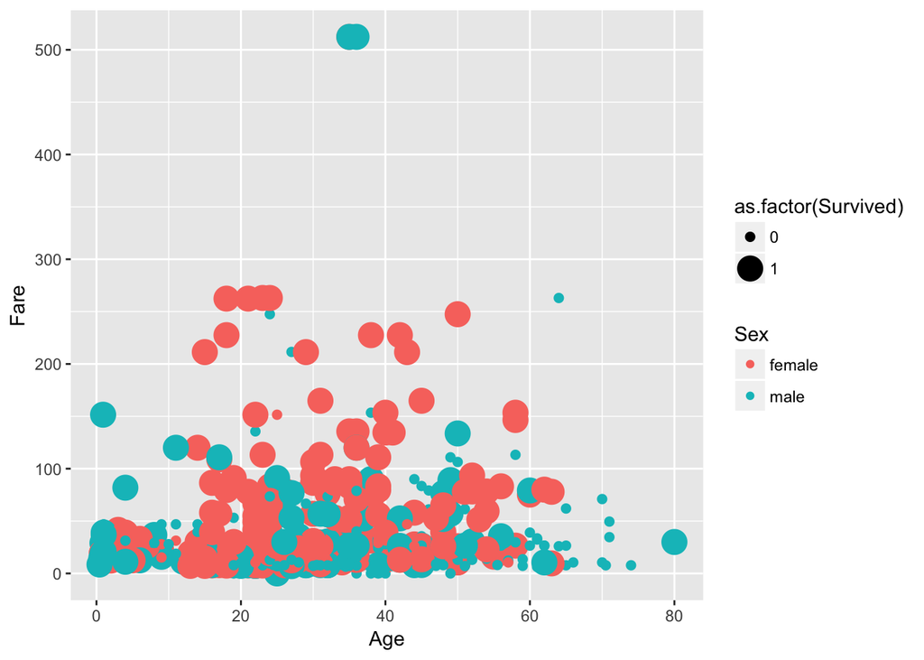

```r
library(ggplot2)

ggplot(data = dfTrain) +
  geom_point(mapping = aes(x = Age, y = Fare, size=as.factor(Survived), color=Sex))
```

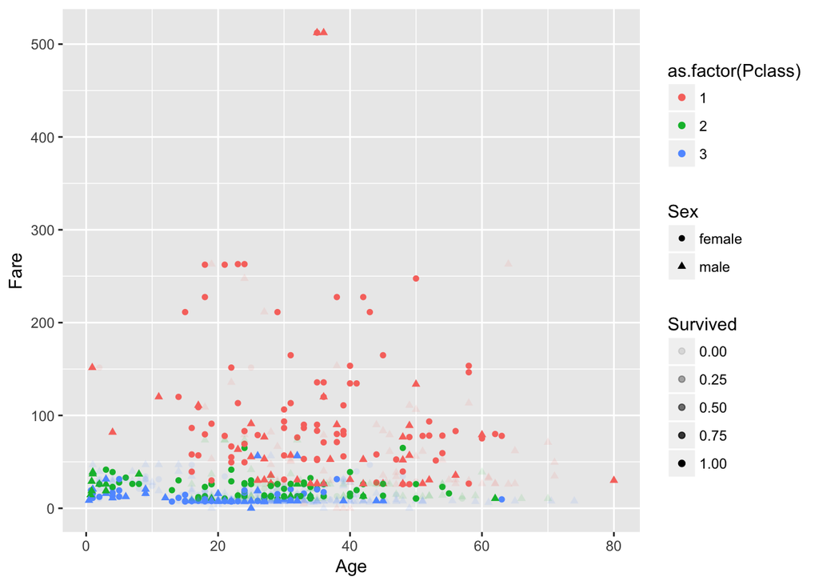

```r
ggplot(data=dfTrain) +
  geom_point(mapping=aes(x=Age, y=Fare, color=as.factor(Pclass), alpha=Survived, shape=Sex))
```

There are many more interesting display variables that can be added with ggplot as well, and many more types of graphs using geom_smooth(), geom_bar(), stat_summary(). Here is an example with geom_bar() counting how many people are in each class.

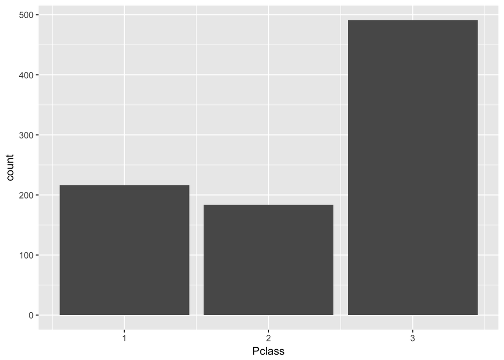

```r
ggplot(data = dfTrain) +
  geom_bar(mapping = aes(x = Pclass, fill=Survived))
```

Here is an example summarizing the age of all the people in a different class.

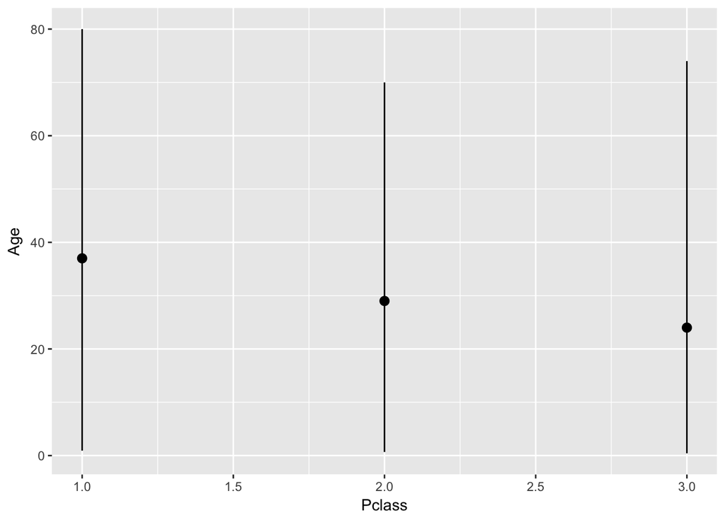

```r
ggplot(data = dfTrain) +
  stat_summary(
    mapping = aes(x = Pclass, y = Age),
    fun.ymin = min,
    fun.ymax = max,
    fun.y = median
  )
```

There are also ways to fill inside the bars and add more details! Those can be found using the associated book.